# t3cp1

15 de agosto de 2016

# Dados gerais

Para termos uma noção geral dos dados, vamos apenas ver quantas propostas de emenda são feitas por ano no Brasil, excluíndo o ano de 2016 já que ainda não temos todo o conjunto de dados desse ano.

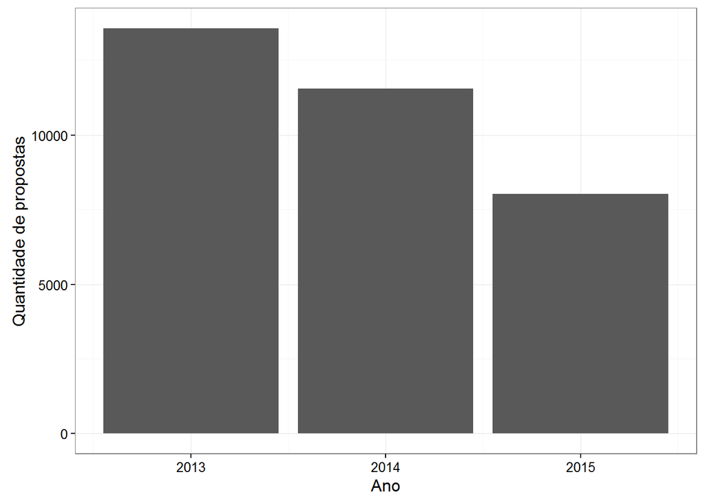

```r
qtdDeEmendasAnual = emendasDetalhes %>%
  select(ANO_PROP, VL_REPASSE_PROP) %>%
  filter(ANO_PROP != 2016) %>%
  group_by(ANO_PROP) %>%
  summarise(qtdAnual = n())

ggplot(qtdDeEmendasAnual) +
  geom_bar(stat="identity", mapping = aes(x = ANO_PROP,
                         y = qtdAnual)) +
    labs(x='Ano', y='Quantidade de propostas')
```

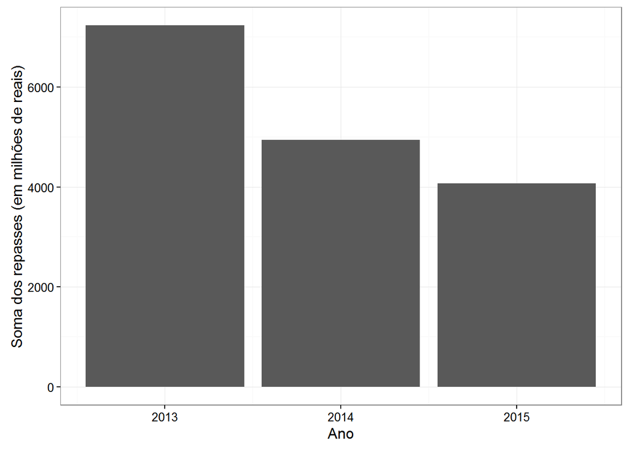

```r
somaDeRepasseAnual = emendasDetalhes %>%
  select(ANO_PROP, VL_REPASSE_PROP) %>%
  filter(ANO_PROP != 2016) %>%
  group_by(ANO_PROP) %>%
  summarise(somaAnual = sum(VL_REPASSE_PROP))

ggplot(somaDeRepasseAnual) +
  geom_bar(stat="identity", mapping = aes(x = ANO_PROP,
                         y = somaAnual/1000000)) +
    labs(x='Ano', y='Soma dos repasses (em milhões de reais)')
```

Realmente! A soma total dos repasses vem caindo desde 2013.

Por curiosidade, vamos ver como é a média do valor dos repasses nesses mesmos anos.

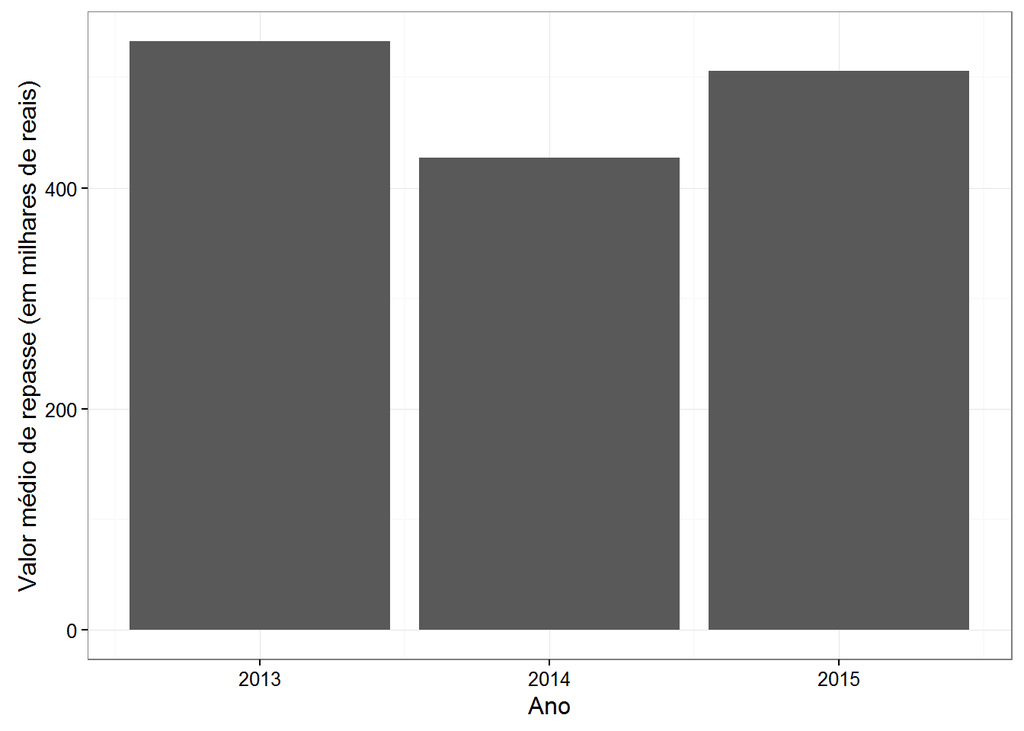

```r
mediaDeRepasseAnual = emendasDetalhes %>%
  select(ANO_PROP, VL_REPASSE_PROP) %>%
  filter(ANO_PROP != 2016) %>%
  group_by(ANO_PROP) %>%
  summarise(mediaAnual = mean(VL_REPASSE_PROP))

ggplot(mediaDeRepasseAnual) +
  geom_bar(stat="identity", mapping = aes(x = ANO_PROP,
                         y = mediaAnual/1000)) +
    labs(x='Ano', y='Valor médio de repasse (em milhares de reais)')
```

O valor médio dos repasses não sofreu tanta mudança como a soma dos valores. Os 3 anos tem valores próximos.

## Dados PB

Agora vamos nos concentrar mais nos dados apenas da Paraíba, isso para facilitar a visualização e para enxergar melhor como são distribuídas as emendas em nosso estado. Trabalharemos daqui em diante com os valores: nome do parlamentar, valor do repasse, valor da contrapartida, funcao para qual o dinheiro foi destinado e o nome do município.

```r
emendasFiltradas = emendasDetalhes %>%
  select(NOME_PARLAMENTAR, VL_REPASSE_PROP, VL_CONTRAPARTIDA_PROP, funcao.imputada, UF_PROPONENTE, MUNIC_PROPONENTE) %>%
  filter(UF_PROPONENTE == "PB")

emendasFiltradas = na.omit(emendasFiltradas)
```

Com o resumo dos valores repassados para os municípios podemos notar que exite uma grande diferença entre o valor mínimo encontrado(49990) e o máximo(3150000), podendo esse máximo ser um outlier pela grande diferença também entre ele e o terceiro quartil(487500).

```r
summary(emendasFiltradas$VL_REPASSE_PROP)
```

```
##    Min. 1st Qu.  Median    Mean 3rd Qu.    Max.
##   49990  245800  295300  433800  487500 3150000
```

Para dar uma visão diferente dos dados, será feito o agrupamento dos mesmos utilizando o método K-means clustering, por ele ser robusto, muito utilizado pela comunidade e escalável.

Como parâmetros do agrupamento serão utilizadas as colunas de valor de repasse e valor de contrapartida, já que são colunas numéricas e que podem nos dar noção dos conjuntos de municípios que receberam maiores repasses, tiveram valoress de contrapartida elevados ou que estão na média.

Baseado em tentantivas de agrupamento realizadas, usaremos a divisão em 5 clusters, pois foi um dos valores que apresentou melhor resultado na divisão.

```r
set.seed(25)
emendasCluster <- kmeans(scale(emendasFiltradas[, 2:3]), 5, nstart = 525)
emendasCluster$cluster <- as.factor(emendasCluster$cluster)

myPlot <- plot_ly(emendasFiltradas, x = VL_REPASSE_PROP, y = VL_CONTRAPARTIDA_PROP, text = paste("Parlamentar: ", NOME_PARLAMENTAR, "Município: ", MUNIC_PROPONENTE), name = "nome", mode = "markers", group = emendasCluster$cluster) %>%
  layout(
      title = "Agrupamento das emedas pelos valores de repasse e contrapartida",
      xaxis = list(title = "Valor de Repasse"),
      yaxis = list(title = "Valor de Contrapartida"),
      margin = list(l = 65)
    )

myPlot
```

[interactive chart not shown]

Feito o agrupamento, podemos notar um grupo bem distindo dos outros que é o 5, com alto valor de contrapartida, outro com valor médios em ambos os eixos(grupo 2), grupos 1 e 4 que poderiam ser um só indicando um valor de repasse relativamente pequeno e o grupo 3 que poderia ser dividido em dois, separando os repasses acima de 2.5 Milhões de reais em outro grupo.

Enfim, pode-se dizer que obtivemos um resultado razoávelmente bom. Isso principalmente pelo fato de que não foi criado um cluster para os pontos com valor de repasse próximo dos 3 Milhões de reais. Mas, os dados também se apresentam na maioria com valores de contrapartida bem próximos, impossibilitando a criação dos grupos mais isolados uns dos outros.